# test 1/2: W2V vs BERT - word to word (context)

[output not shown]

## DATA

dataset with mannual annotation of similaraties between pairs of words (wordsim353);

| w1 | w2 | score |
| --- | --- | --- |
| love | sex | 6.77 |
| tiger | cat | 7.35 |
| tiger | tiger | 10.00 |
| book | paper | 7.46 |
| computer | keyboard | 7.62 |
| computer | internet | 7.58 |

and dataset with vector representations (w2v) of the set of words appeared (we show only the first two dimensions);

| id | w | id_token | token | dim_1 | dim_2 |
| --- | --- | --- | --- | --- | --- |
| 1 | love | 1 | i | -0.22558594 | -0.01953125 |
| 1 | love | 2 | love | 0.10302734 | -0.15234375 |
| 1 | love | 3 | you | 0.20410156 | 0.01318359 |
| 2 | tiger | 1 | i | -0.22558594 | -0.01953125 |
| 2 | tiger | 2 | saw | 0.09423828 | 0.20117188 |
| 2 | tiger | 3 | tiger | -0.06835938 | 0.18261719 |

we select rows with equal w and token

NOTE: w2v is context-free but we could test it.

Also, we have our BERT representations (free-context) in this way,

| id | w | id_token | token | dim_w_1 | dim_w_2 |
| --- | --- | --- | --- | --- | --- |
| 1 | love | 1 | love | 0.38649017 | 0.36187920 |
| 2 | tiger | 1 | tiger | -0.30712840 | -0.31644982 |
| 3 | book | 1 | book | 0.41267234 | -0.00370523 |
| 4 | computer | 1 | computer | -0.67297429 | -0.10599531 |
| 5 | plane | 1 | plane | 0.01826328 | -0.21225268 |
| 6 | train | 1 | train | -0.52878708 | -1.14276505 |

```
[1] 428
[1] 428
```

Firstly, we remove words that we haven’t in both datasets (4 words are lost in w2v dataset because are out-of-vocabulary). Now, we can compute (cosine) similarities between vector representations (w2v and BERT) pairs of words in “data_sim” and compare with the mannual scoring.

| w1 | w2 | score | w2v_cosine | bert_cosine |
| --- | --- | --- | --- | --- |
| love | sex | 6.77 | 0.2639377 | 0.6756448 |
| tiger | cat | 7.35 | 0.5172962 | 0.7996021 |
| tiger | tiger | 10.00 | 1.0000000 | 1.0000000 |
| book | paper | 7.46 | 0.3634626 | 0.5779281 |
| computer | keyboard | 7.62 | 0.3963916 | 0.8194257 |
| computer | internet | 7.58 | 0.4068623 | 0.5341467 |

With this dataset we can compare mannual similarity with cosine metric for w2v and BERT representations.

## ANALYSIS

We clean NA puntuations, and we get 328 complete rows.

NOTE: we observe 3 values of cosine (w2v) < 0

| w1 | w2 | score | w2v_cosine | bert_cosine |
| --- | --- | --- | --- | --- |
| precedent | cognition | 2.81 | -0.0205696013 | 0.6433847 |
| mars | water | 2.94 | -0.0009222099 | 0.5781125 |
| preservation | world | 6.19 | -0.0214706240 | 0.6177243 |

We can plot similarities scores,

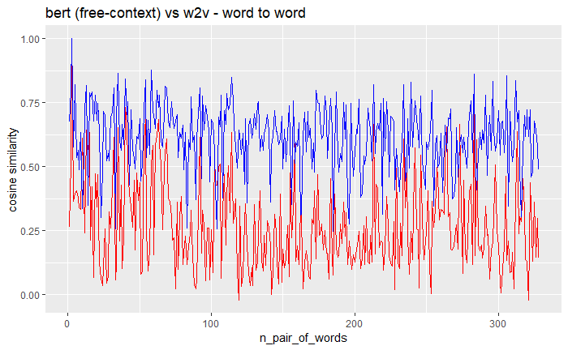

We can observe the best results for BERT representations.

Also we can compute the Pearson coefficient in both case respect to the mannual scores in dataset. For w2vec similarities,

```r
cor(data_sim$score, data_sim$w2v_cosine, method = c("pearson"))
```

```
[1] 0.655213
```

and for BERT cosine similarities,

```r
cor(data_sim$score, data_sim$bert_cosine, method = c("pearson"))
```

```
[1] 0.2467143
```

We can observe highest similarity metric for BERT representations, but has a worst correlation with mannual scoring.

And corrlation between both vector representations scoring is,

```r
cor(data_sim$w2v_cosine, data_sim$bert_cosine, method = c("pearson"))
```

```
[1] 0.3178288
```

### BERT non-free-context

Now, we can use the BERT vector representation of the same word got from word in a phrase (context).

In the next dataset we have a phrase containing the word and we have the vector representation got in this case,

| id | w | id_token | token | dim_context_1 | dim_context_2 | dim_context_3 | dim_context_4 | dim_context_5 | dim_context_6 | dim_context_7 | dim_context_8 | dim_context_9 | dim_context_10 | dim_context_11 | dim_context_12 | dim_context_13 | dim_context_14 | dim_context_15 | dim_context_16 | dim_context_17 | dim_context_18 | dim_context_19 | dim_context_20 | dim_context_21 | dim_context_22 | dim_context_23 | dim_context_24 | dim_context_25 | dim_context_26 | … |
| --- | --- | --- | --- | --- | --- | --- | --- | --- | --- | --- | --- | --- | --- | --- | --- | --- | --- | --- | --- | --- | --- | --- | --- | --- | --- | --- | --- | --- | --- | --- |
| 1 | love | 1 | i | 0.2335791 | 0.24898028 | -0.10874116 | -0.61140013 | 0.27673605 | 0.1779147 | 0.27945131 | 1.2248502 | -0.119075179 | -0.09032473 | -0.32646716 | -0.6783785 | -0.4773986 | 0.5253544 | 0.48776215 | -0.1147995 | 0.004324459 | 0.03994677 | 0.033803500 | 0.346627772 | 0.31664035 | -0.03500282 | -1.1976421 | 0.5543277 | 0.258402973 | 0.06867822 | … |
| 1 | love | 2 | love | 0.9315368 | 0.91580886 | 1.12545121 | -0.65521735 | 0.79098934 | -0.1220527 | 0.07009090 | 0.8078827 | -0.329654157 | -0.06828035 | -0.38360804 | -0.6908240 | -0.8863937 | 0.4029942 | 0.10526662 | 0.1177355 | -0.051804610 | -0.04071184 | 0.571894765 | 0.202084497 | 0.09963282 | 0.32294685 | -0.7396824 | 0.5910242 | 0.254506916 | -0.25677556 | … |
| 1 | love | 3 | you | -0.1724851 | -0.77048999 | 0.82299870 | 0.41200000 | -0.16357306 | -0.4911228 | 0.37228057 | 1.1801692 | -0.480131060 | 0.47210416 | -0.24674924 | 0.2328498 | -0.1401320 | 1.0515803 | -0.02302222 | 0.3939849 | -0.322798640 | 0.78963286 | 0.230677605 | 1.489722848 | 0.00745938 | 0.30999818 | -0.3857818 | -0.4451788 | 0.130777583 | -0.28346282 | … |
| 2 | tiger | 1 | i | 0.1126512 | -0.53610945 | -0.07686315 | 0.11803754 | 0.02298248 | 0.5733222 | -0.38666618 | 1.3493119 | 0.678333998 | -0.54966438 | -0.37814605 | -0.6191993 | -0.1865057 | 0.3956201 | 0.05871640 | -0.6440876 | 0.794383526 | -0.03277098 | 0.133735433 | 0.653085291 | 0.19973609 | 0.01915376 | -1.0020963 | 0.8645376 | -0.006010648 | -0.05506191 | … |
| 2 | tiger | 2 | saw | -0.1356604 | -0.20776120 | -0.44468316 | -0.36666375 | 0.07165144 | 0.4999209 | -0.06827904 | 1.3866686 | -0.009259509 | -0.29952893 | 0.01516415 | -0.4427828 | 0.1980091 | -0.1448311 | 0.09307747 | -0.1881676 | -0.180668890 | -0.53239697 | 0.004892424 | -0.019908750 | 0.25702867 | -0.26862839 | -0.4999551 | 0.2722155 | -0.072505586 | 0.45105034 | … |
| 2 | tiger | 3 | a | -0.2600941 | -0.07189066 | -0.86441523 | -0.02332758 | 0.45594415 | 0.1629293 | 0.50674123 | 1.1121476 | -0.418714255 | 0.11117770 | -0.09162806 | -0.7756641 | -0.3486095 | 0.6697188 | 0.11562596 | -0.1708484 | -0.081081949 | -0.36878055 | 0.079213664 | 0.002561518 | -0.55743146 | -0.42775908 | -0.6656384 | 0.1379898 | 0.154559270 | 0.04314984 | … |

and we select the corresponding vector,

| id | w | dim_context_1 | dim_context_2 |
| --- | --- | --- | --- |
| 1 | love | 0.9315368 | 0.9158089 |
| 2 | tiger | 0.3108854 | 0.1306733 |
| 3 | book | 0.1590683 | -0.4085730 |
| 4 | computer | -0.4819463 | 0.2318698 |
| 5 | plane | 1.0386617 | -0.6260117 |
| 6 | train | 1.0346285 | -0.8108625 |

[output not shown]

in this case the before results are,

```r
cor(data_sim$score, data_sim$bert_context_cosine, method = c("pearson"))
```

```
[1] 0.3516758
```

we can observe a bit improve respect to results with BERT free-context.